# Intrinsic Potential for Chinook Salmon in the Klamath Basin

Maddee Wiggins (FlowWest)

2026-03-26

## Objective

Calculate the intrinsic potential for Chinook salmon in the Klamath basin rivers and streams

## Aggregate and Process Data

### Flowlines

Source:

- NHDplus geodatabase downloaded from: https://www.sciencebase.gov/catalog/item/5d30c29ae4b01d82ce84aa5e
- NHDplus user guide: https://pubs.usgs.gov/of/2019/1096/ofr20191096.pdf

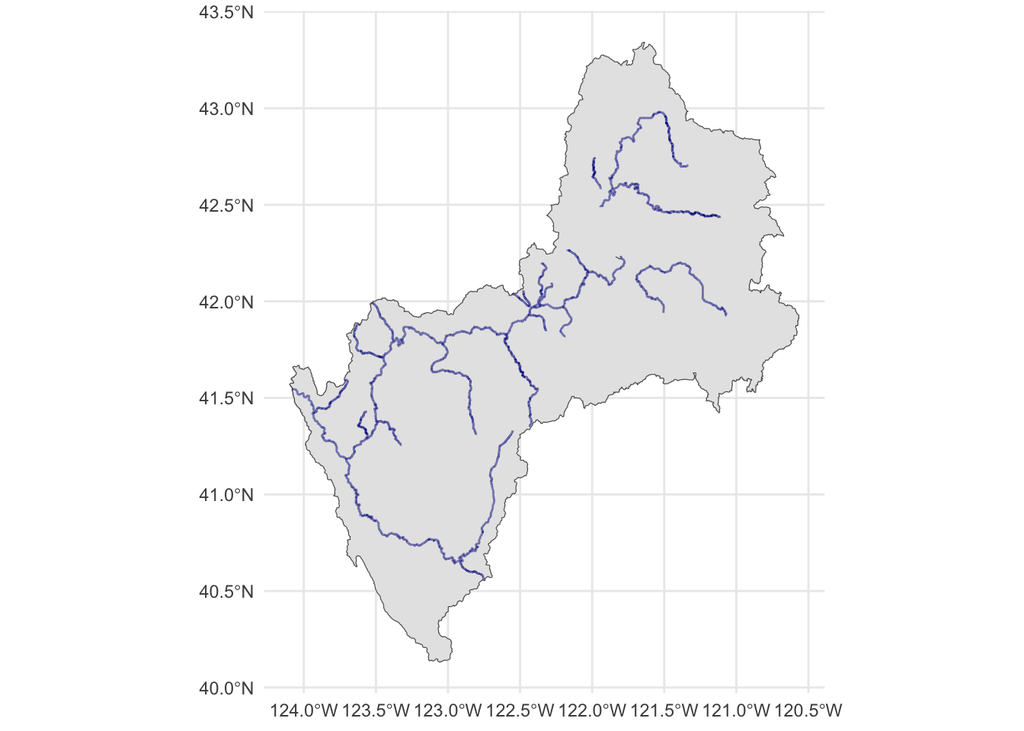

```r
ggplot() +
  geom_sf(data = rivermile::klamath_hucs |> st_union()) +
  geom_sf(data = flowlines, color = "darkblue", alpha = 0.5) +
  theme_minimal()
```

### Slope

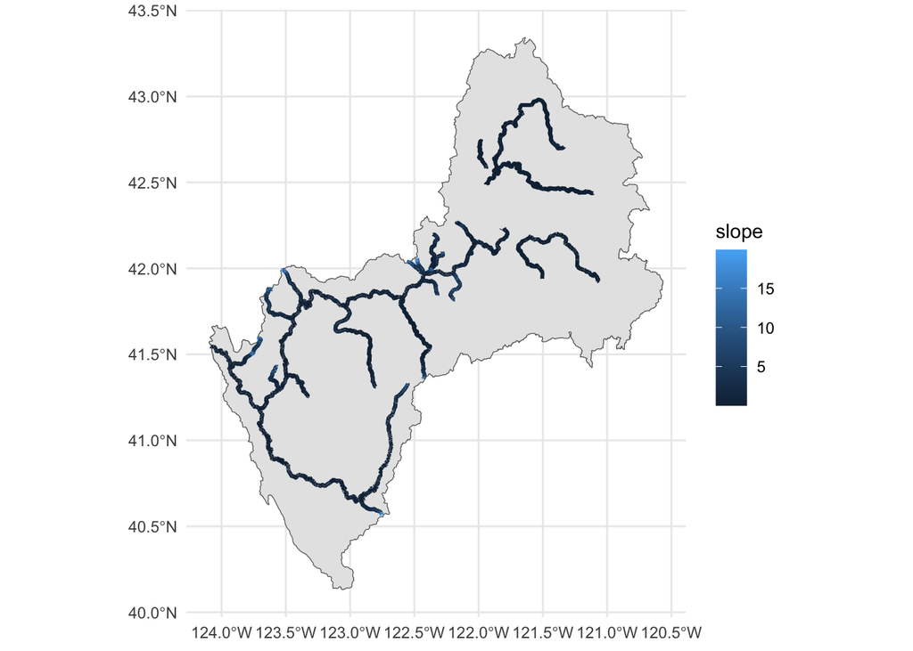

| gnis_nm | min_slope | max_slope | mean_slope | median_slope |
| --- | --- | --- | --- | --- |
| Blue Creek | 0.0 | 30.9 | 3.3 | 1.7 |
| Bogus Creek | 0.0 | 8.4 | 2.7 | 2.4 |
| Camp Creek | 0.0 | 75.3 | 6.2 | 3.3 |
| Clear Creek | 0.0 | 31.2 | 2.7 | 2.0 |
| Fall Creek | 0.0 | 11.5 | 3.1 | 2.1 |
| Indian Creek | 0.0 | 41.7 | 4.3 | 2.0 |
| Jenny Creek | 0.0 | 8.6 | 0.9 | 0.5 |
| Klamath River | 0.0 | 13.0 | 0.3 | 0.2 |
| Link River | 0.0 | 1.0 | 0.5 | 0.4 |
| Lost River | 0.0 | 3.1 | 0.2 | 0.0 |
| Salmon River | 0.0 | 15.6 | 1.1 | 0.4 |
| Scotch Creek | 0.0 | 21.4 | 6.2 | 4.6 |
| Scott River | 0.0 | 17.0 | 0.6 | 0.4 |
| Shasta River | 0.0 | 30.7 | 1.5 | 0.4 |
| Shovel Creek | 0.4 | 21.2 | 4.1 | 3.3 |
| Spencer Creek | 0.0 | 5.9 | 1.3 | 0.6 |
| Sprague River | 0.0 | 1.3 | 0.0 | 0.0 |
| Trinity River | 0.0 | 25.0 | 0.7 | 0.0 |
| Williamson River | 0.0 | 2.2 | 0.2 | 0.0 |
| Wood River | 0.0 | 0.2 | 0.0 | 0.0 |

```r
ggplot() +
  geom_sf(data = rivermile::klamath_hucs |> st_union()) +
  geom_sf(data = flowlines_ip_layers |> filter(slope < 20), # did this for the visusal since most of the values are below 20%
          aes(color = slope), size = 1) +
  theme_minimal()
```

### Total Drainage Area (sqkm)

This value is part of the NHD network

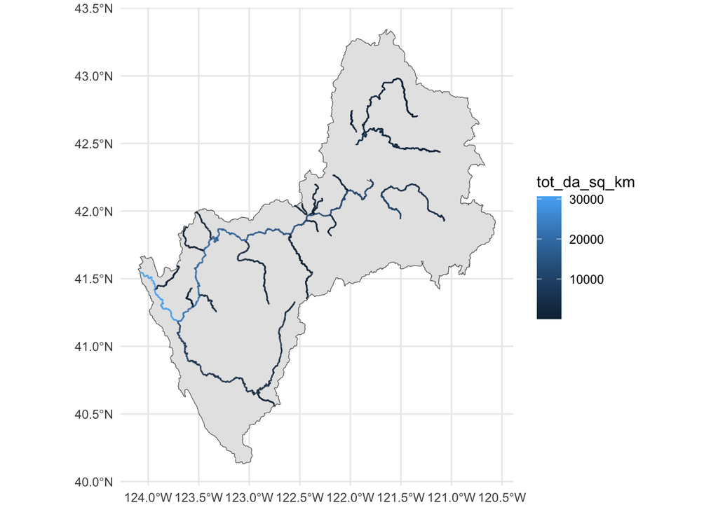

```r
ggplot() +
  geom_sf(data = rivermile::klamath_hucs |> st_union()) +
  geom_sf(data = flowlines_ip_layers, aes(color = tot_da_sq_km)) +
  theme_minimal()
```

### Estimated Discharge

There is likely a better way to do this with USGS gages however since the Chinook suitability is 1 for a discharge greater than zero, it doesn’t seem worthwhile.

**double check source** source: https://ui.adsabs.harvard.edu/abs/2018AGUFMEP21D2294W/abstract#:~:text=Geomorphologists%20often%20use%20drainage%20area%20as%20a,exponent%20decreases%20as%20flood%20recurrence%20interval%20increases.

```r
estimate_discharge <- function(area_km2) {
  discharge <- 0.028 * area_km2^0.89
  return(discharge)
}

flowlines_ip_layers <- flowlines_ip_layers |>
  mutate(discharge_mean_est = estimate_discharge(tot_da_sq_km))
```

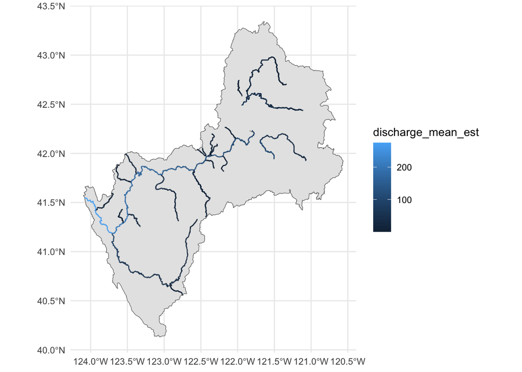

| gnis_nm | min_discharge_mean_est | max_discharge_mean_est | mean_discharge_mean_est | median_discharge_mean_est |
| --- | --- | --- | --- | --- |
| Blue Creek | 0.0 | 4.8 | 2.8 | 3.8 |
| Bogus Creek | 0.5 | 2.2 | 1.4 | 1.2 |
| Camp Creek | 0.0 | 1.8 | 0.7 | 0.6 |
| Clear Creek | 0.0 | 4.3 | 2.2 | 2.3 |
| Fall Creek | 0.0 | 0.7 | 0.4 | 0.4 |
| Indian Creek | 0.0 | 5.1 | 1.9 | 1.3 |
| Jenny Creek | 1.6 | 7.6 | 5.7 | 6.7 |
| Klamath River | 71.9 | 275.3 | 169.8 | 165.5 |
| Link River | 71.8 | 71.8 | 71.8 | 71.8 |
| Lost River | 20.0 | 103.4 | 37.7 | 33.6 |
| Salmon River | 16.3 | 23.7 | 19.2 | 18.6 |
| Scotch Creek | 0.0 | 0.9 | 0.4 | 0.3 |
| Scott River | 5.8 | 23.6 | 15.3 | 18.8 |
| Shasta River | 0.0 | 15.7 | 8.3 | 7.6 |
| Shovel Creek | 0.1 | 2.1 | 1.2 | 1.2 |
| Spencer Creek | 0.8 | 3.3 | 2.3 | 2.0 |
| Sprague River | 15.8 | 41.0 | 25.8 | 30.7 |
| Trinity River | 0.3 | 80.1 | 37.4 | 33.9 |
| Williamson River | 0.1 | 57.2 | 10.3 | 8.4 |
| Wood River | 0.0 | 2.9 | 2.3 | 2.4 |

```r
ggplot() +
  geom_sf(data = rivermile::klamath_hucs |> st_union()) +
  geom_sf(data = flowlines_ip_layers, aes(color = discharge_mean_est)) +
  theme_minimal()
```

### Bankfull Width

Source: [Bieger model](https://swat.tamu.edu/media/114657/bieger_etal_2015.pdf) $2.76 * DA^.399$

```r
flowlines_ip_layers <- flowlines_ip_layers |>
  mutate(bf_width_m = 2.76 * tot_da_sq_km^0.399)
```

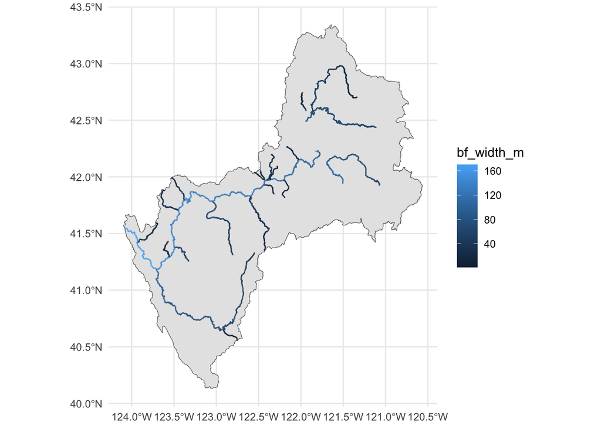

```r
ggplot() +
  geom_sf(data = rivermile::klamath_hucs |> st_union()) +
  geom_sf(data = flowlines_ip_layers, aes(color = bf_width_m)) +
  theme_minimal()
```

### Valley Bottom Width

Calculated using Valley Confinement methodology outlined in [South Fork Eel River Basin Geomorphic Classification](https://watermanagement.ucdavis.edu/download_file/view_inline/144) and implemented through [Habistat](https://github.com/FlowWest/habistat/blob/main/data-raw/scripts/terrain-attributes.md#valley-bottom-width-via-slope-cutoff-method). Code adapted to fit the needs of this project.

```r
valley_bottom <- function(catchment, flowline, dem) {
  dem |>
    st_crop(catchment) |>
    st_as_stars() |>
    starsExtra::slope() |>
    mutate(valley_bottom = if_else(slope<units::set_units(atan(0.25)*180/pi,"degrees"), 1, NA)) |>
    select(valley_bottom) |>
    st_as_sf(merge=TRUE) |>
    st_filter(st_zm(flowline))
}

valley_bottom_by_comid <- function(x, dem, catchment, flowlines) {
  c <- catchments |>
    mutate(nhdplusid = as.character(nhdplusid)) |>
    filter(nhdplusid==x) |>
    st_transform(st_crs(dem))
  f <- flowlines |>
    mutate(nhdplusid = as.character(nhdplusid)) |>
    filter(nhdplusid==x) |>
    st_transform(st_crs(dem))
  valley_bottom(c, f, dem)
}

valley_width_naive <- function(geom_valley_bottom) {
  geom_valley_bottom |>
    terra::vect() |>
    terra::width()
}

perpendicular_transect <- function(pair, transect_length) {
  p1 <- st_coordinates(st_sfc(pair[[1]]))
  p2 <- st_coordinates(st_sfc(pair[[2]]))

  x1 <- p1[1, "X"]
  y1 <- p1[1, "Y"]
  x2 <- p2[1, "X"]
  y2 <- p2[1, "Y"]

  midpoint_x <- (x1 + x2) / 2
  midpoint_y <- (y1 + y2) / 2

  orig_bearing <- atan2(y2 - y1, x2 - x1)
  perp_bearing <- orig_bearing + pi / 2

  radius <- transect_length / 2

  perp_x1 <- midpoint_x + radius * cos(perp_bearing)
  perp_y1 <- midpoint_y + radius * sin(perp_bearing)
  perp_x2 <- midpoint_x - radius * cos(perp_bearing)
  perp_y2 <- midpoint_y - radius * sin(perp_bearing)

  st_linestring(matrix(
    c(perp_x1, perp_y1,
      perp_x2, perp_y2),
    ncol = 2,
    byrow = TRUE
  ))
}

perpendicular_transects <- function(ls, transect_length) {
  if (inherits(ls, "sf")) {
    crs_use <- st_crs(ls)
    ls <- st_geometry(ls)
  } else if (inherits(ls, "sfc")) {
    crs_use <- st_crs(ls)
  } else if (inherits(ls, "sfg")) {
    crs_use <- NA
    ls <- st_sfc(ls)
  } else {
    stop("ls must be sf, sfc, or sfg")
  }

  coords <- st_coordinates(st_zm(ls))[, 1:2, drop = FALSE]

  if (nrow(coords) < 2) {
    stop("Need at least 2 coordinates to build transects")
  }

  point_pairs <- lapply(seq_len(nrow(coords) - 1), function(i) {
    list(
      st_point(coords[i, ]),
      st_point(coords[i + 1, ])
    )
  })

  perp_lines <- lapply(point_pairs, function(pair) {
    perpendicular_transect(pair, transect_length)
  })

  st_sfc(perp_lines, crs = crs_use)
}

valley_width_via_transects <- function(geom_valley_bottom, flowline, max_width) {
  transects <- perpendicular_transects(flowline, transect_length = max_width)
  if("sfg" %in% class(geom_valley_bottom)) {
    geom_valley_bottom <- st_sfc(geom_valley_bottom, crs=st_crs(transects))
  }
  clipped <- st_intersection(transects, geom_valley_bottom)
  return(mean(st_length(clipped)))
}
```

```r
catch <- catchments |>
  filter(nhdplusid == '50000400209014')
flow <- flowlines_ip_layers |>
  mutate(nhdplusid = as.character(nhdplusid)) |>
  filter(nhdplusid == '50000400209014') |>
  st_transform(st_crs(dem))

valley_polygon <- valley_bottom(catch, flow, dem)
valley_width_via_transects(valley_bottom(catch, flow, dem), flow, max_width=1000)
```

```
## 161.7149 [m]
```

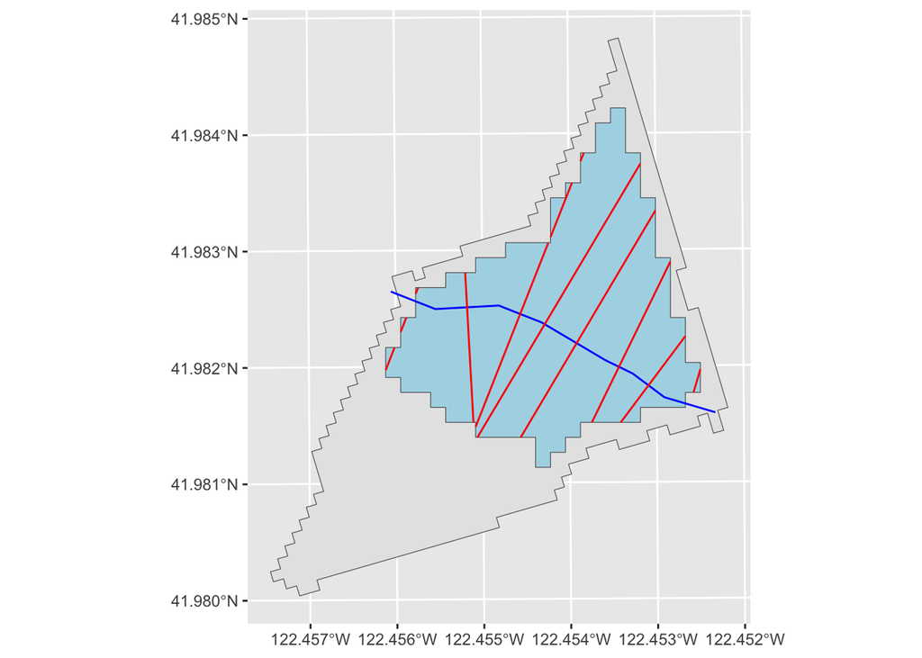

```r
ggplot() +
  geom_sf(data=catch) +
  geom_sf(data=valley_polygon, fill="lightblue") +
  geom_sf(data=flow, color="blue") +
  geom_sf(data=perpendicular_transects(flow, transect_length=1000) |> st_intersection(valley_polygon), color="red")
```

### Valley Width Index

$V = (valley-floor-width)/(active-channel-width)$

```r
flowlines_ip_layers_all <- flowlines_ip_layers_new |>
  mutate(valley_width_index = vb_width_transect/bf_width_m)
```

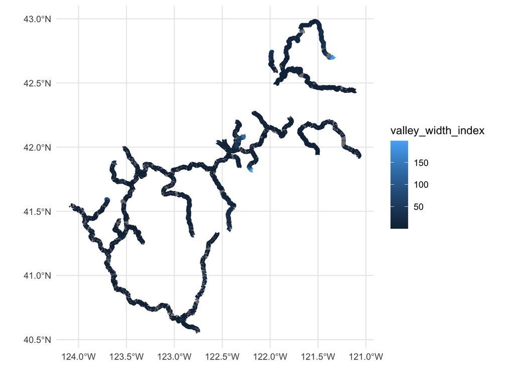

| gnis_nm | min_valley_width_index | max_valley_width_index | mean_valley_width_index | median_valley_width_index |
| --- | --- | --- | --- | --- |
| Blue Creek | 0.2 | 86.4 | 5.2 | 3.0 |
| Bogus Creek | 1.1 | 38.4 | 6.3 | 2.9 |
| Camp Creek | 0.1 | 24.1 | 3.3 | 2.5 |
| Clear Creek | 0.4 | 47.0 | 4.7 | 1.8 |
| Fall Creek | 1.5 | 138.0 | 36.2 | 26.1 |
| Indian Creek | 0.5 | 28.1 | 5.0 | 3.8 |
| Jenny Creek | 0.2 | 22.6 | 3.1 | 2.1 |
| Klamath River | 0.0 | 8.5 | 1.0 | 0.7 |
| Link River | 2.9 | 4.9 | 3.9 | 3.9 |
| Lost River | 0.0 | 14.7 | 4.2 | 3.7 |
| Salmon River | 0.2 | 7.2 | 1.5 | 0.9 |
| Scotch Creek | 0.1 | 139.1 | 9.7 | 4.3 |
| Scott River | 0.0 | 24.0 | 3.9 | 2.1 |
| Shasta River | 0.2 | 41.0 | 10.5 | 7.4 |
| Shovel Creek | 0.6 | 198.6 | 24.8 | 2.7 |
| Spencer Creek | 1.4 | 29.6 | 8.2 | 6.5 |
| Sprague River | 0.2 | 13.1 | 5.0 | 4.3 |
| Trinity River | 0.1 | 24.0 | 2.6 | 1.3 |
| Williamson River | 0.7 | 196.5 | 19.6 | 12.4 |
| Wood River | 0.8 | 60.9 | 11.3 | 6.5 |

```r
ggplot() +
  geom_sf(data = flowlines_ip_layers_all, aes(color = valley_width_index), size = 2) +
  theme_minimal()
```

### Suitability Criteria

Source: https://www.fs.usda.gov/pnw/pubs/journals/pnw_2005_agrawal001.pdf

In addition to the above source, we looked into the following literature to see if the suitability significantly varied. Overall, this seems consistent for Chinook Salmon.

- https://www.fs.usda.gov/pnw/pubs/journals/pnw_2013_busch001.pdf
- https://pubs.usgs.gov/publication/ofr20231077/

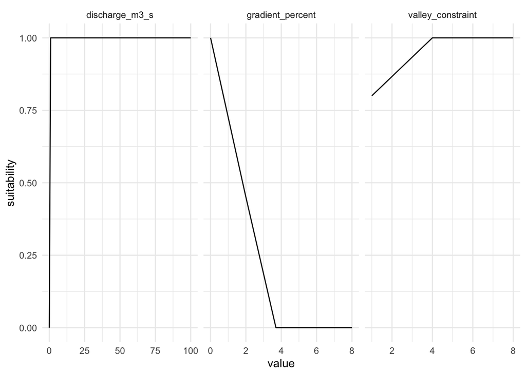

```r
chinook_suit <- tibble(
  variable = c(
    rep("gradient_percent", 4),
    rep("valley_constraint", 4),
    rep("discharge_m3_s", 4)
  ),
  value = c(
    0,  2, 3.7, 8,
    1, 2.5, 4, 8,
    0, 1, 100, 100
  ),
  suitability = c(
    1.0, 0.45, 0.0, 0.0,
    0.8, 0.9, 1.0, 1.0,
    0.0, 1, 1, 1.0
  )
)

ggplot() +
  geom_line(data = chinook_suit, aes(x = value, y = suitability)) +
  facet_wrap(~variable, scales = "free_x") +
  theme_minimal()
```

# IP Calculation Approach 1:

### for each NHD segment:

```r
ip <- flowlines_ip_layers_all |>
  mutate(
    suit_slope = slope_fun(slope),
    suit_valley = valley_fun(valley_width_index),
    suit_q = q_fun(discharge_mean_est),
    chinook_ip = (suit_slope * suit_valley * suit_q)^(1/3)
  ) |>
  mutate(
    chinook_ip_class = case_when(
      is.na(chinook_ip) ~ NA_character_,
      chinook_ip < 0.25 ~ "low",
      chinook_ip < 0.5  ~ "moderate",
      chinook_ip < 0.75 ~ "high",
      TRUE ~ "very high"
    )
  )
```

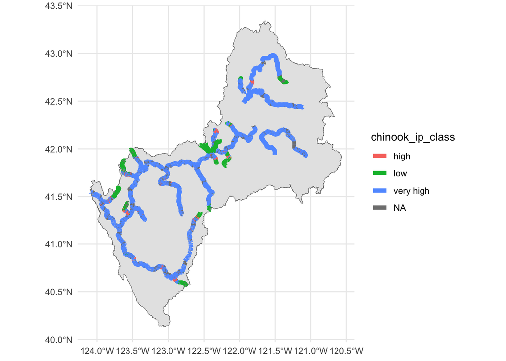

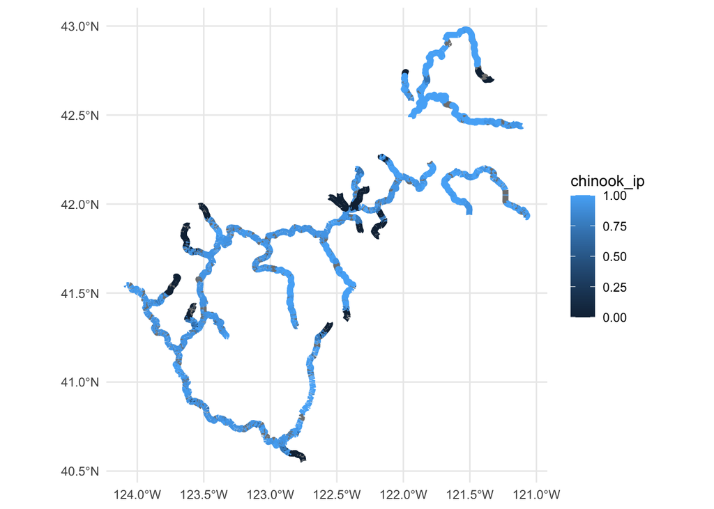

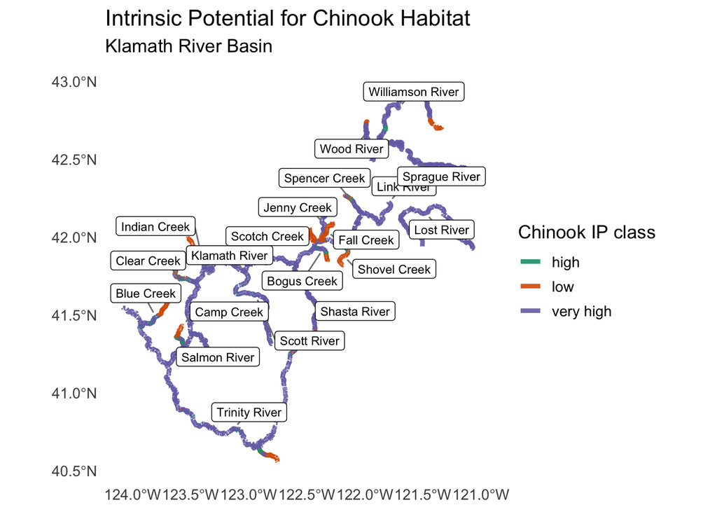

### For each river:

```r
ip_river <- flowlines_ip_layers_all |>
  group_by(gnis_nm) |>
  summarise(slope = mean(slope, na.rm = T),
            valley_width_index = mean(valley_width_index, na.rm = T),
            discharge_mean_est = mean(discharge_mean_est, na.rm = T)) |>
  mutate(
    suit_slope = slope_fun(slope),
    suit_valley = valley_fun(valley_width_index),
    suit_q = q_fun(discharge_mean_est),
    chinook_ip = (suit_slope * suit_valley * suit_q)^(1/3)
  ) |>
  mutate(
    chinook_ip_class = case_when(
      is.na(chinook_ip) ~ NA_character_,
      chinook_ip < 0.25 ~ "low",
      chinook_ip < 0.5  ~ "moderate",
      chinook_ip < 0.75 ~ "high",
      TRUE ~ "very high"
    )
  )
```

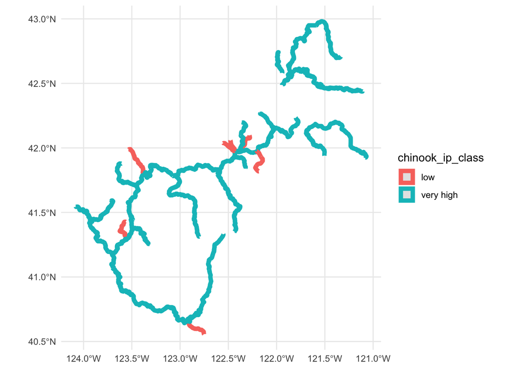

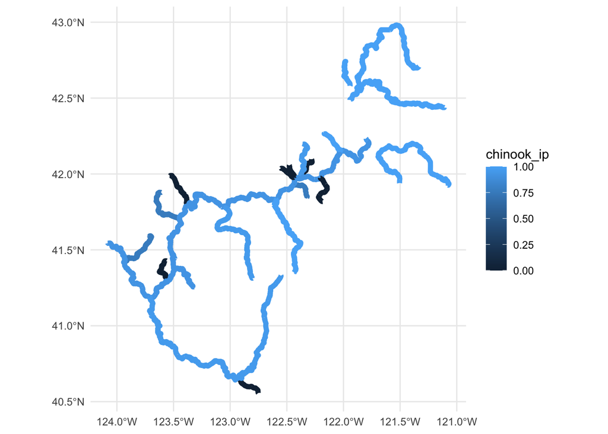

| gnis_nm | mean_ip | min_ip | max_ip |
| --- | --- | --- | --- |
| Blue Creek | 0.58 | 0.00 | 1.00 |
| Bogus Creek | 0.51 | 0.00 | 1.00 |
| Camp Creek | 0.27 | 0.00 | 1.00 |
| Clear Creek | 0.53 | 0.00 | 1.00 |
| Fall Creek | 0.00 | 0.00 | 0.00 |
| Indian Creek | 0.49 | 0.00 | 1.00 |
| Jenny Creek | 0.88 | 0.00 | 1.00 |
| Klamath River | 0.92 | 0.00 | 1.00 |
| Link River | 0.98 | 0.97 | 1.00 |
| Lost River | 0.96 | 0.71 | 1.00 |
| Salmon River | 0.90 | 0.00 | 1.00 |
| Scotch Creek | 0.00 | 0.00 | 0.00 |
| Scott River | 0.94 | 0.00 | 1.00 |
| Shasta River | 0.89 | 0.00 | 1.00 |
| Shovel Creek | 0.25 | 0.00 | 0.97 |
| Spencer Creek | 0.83 | 0.00 | 1.00 |
| Sprague River | 0.97 | 0.93 | 1.00 |
| Trinity River | 0.90 | 0.00 | 1.00 |
| Williamson River | 0.90 | 0.00 | 1.00 |
| Wood River | 0.85 | 0.00 | 1.00 |

### Data Questions

1. *How do we want the final dataset to be structured? Is it reasonable to summarize by reach?*
2. *Do the values seem reasonable? It seems to be heavily driven by slope and some by valley constraint*
3. *Are there any other datasets that would be beneficial to include?*

# IP Calculation Approach 2:

### A weight based approach to Intrinsic Potential:

Intrinsic Potential (IP) modeling scores every stream reach in the network based on four physical channel attributes — gradient, valley confinement, drainage area, and bankfull width — to identify reaches most likely to support fall Chinook salmon spawning. Thresholds for each variable are drawn from published literature and combined into a weighted score, classifying reaches from Very Low to Very High potential. A key feature of the approach is that all reaches are evaluated equally regardless of survey coverage, treating the absence of fish observations as a gap in knowledge rather than evidence of absence. Variable thresholds and weights represent the best available starting point from the literature, and we welcome local expertise to help refine them for this basin. We intend to validate IP classifications using fish presence data and spawning gravel surveys, though that dataset is not yet available.

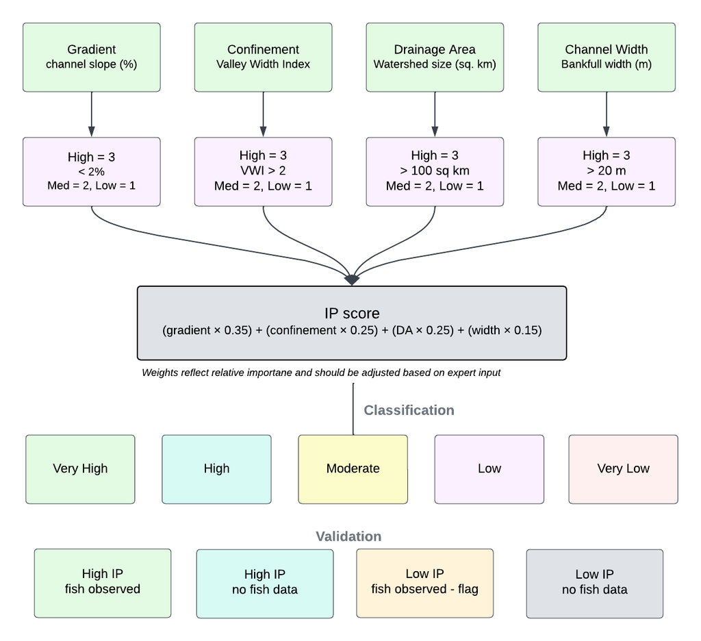

**Spawning Gravel**

RES did spawning gravel surveys for the reservoir footprint and some tributaries. This data could be useful in further refinement of the IP calculation.

source: [spawning gravel survey data](https://klamath-data-management-platform-klamath.hub.arcgis.com/maps/92cad013db7c445f87194f09e8fcc71e):

| survey_reac | total_patch_size_c |
| --- | --- |
| Beaver Creek | 102 |
| Camp-Scotch Creek Complex | 563 |
| Copco Reservoir Footprint | 18562 |
| Fall Creek | 94 |
| Iron Gate Reservoir Footprint | 1182 |
| J. C. Boyle Reservoir Footprint | 18855 |
| Jenny Creek | 1672 |
| Shovel Creek | 619 |
| Spencer Creek | 4709 |
| Spring Island to Stateline | 5703 |
| Stateline to Copco | 542 |

### Data Exploration

Look at the distribution of each of the layers used to calculate IP

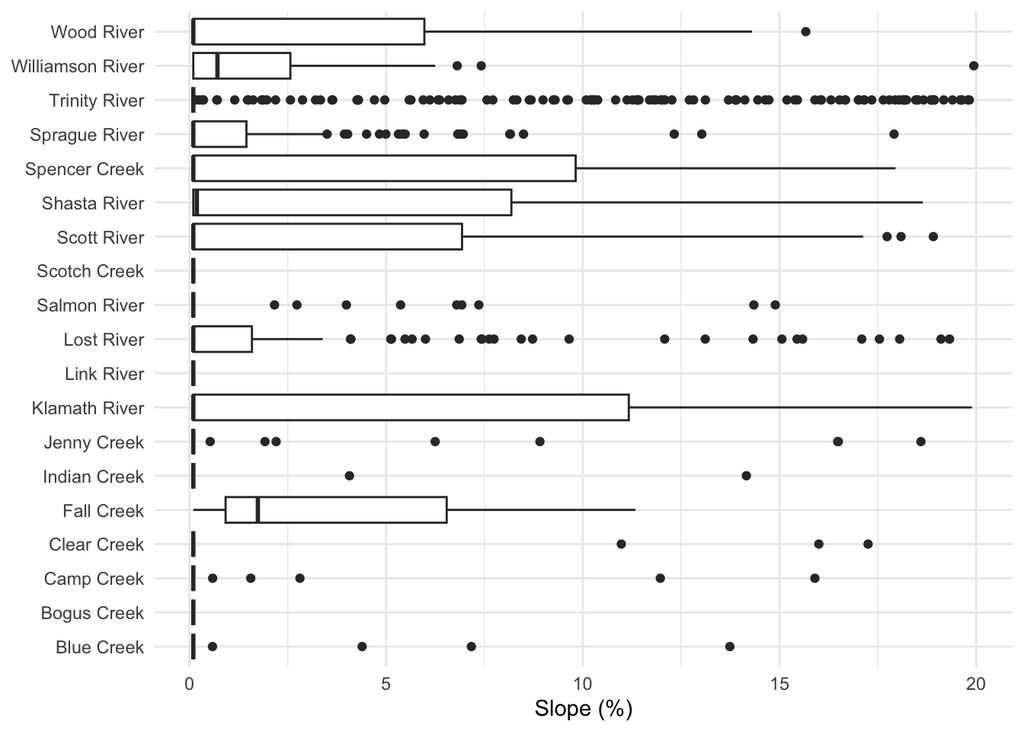

```r
ggplot(flowlines_ip_layers_all |>
         filter(slope * 100 < 20)) +
  geom_boxplot(aes(x = gnis_nm, y = slope * 100)) +
  coord_flip() +
  labs(x = NULL, y = "Slope (%)") +
  theme_minimal()
```

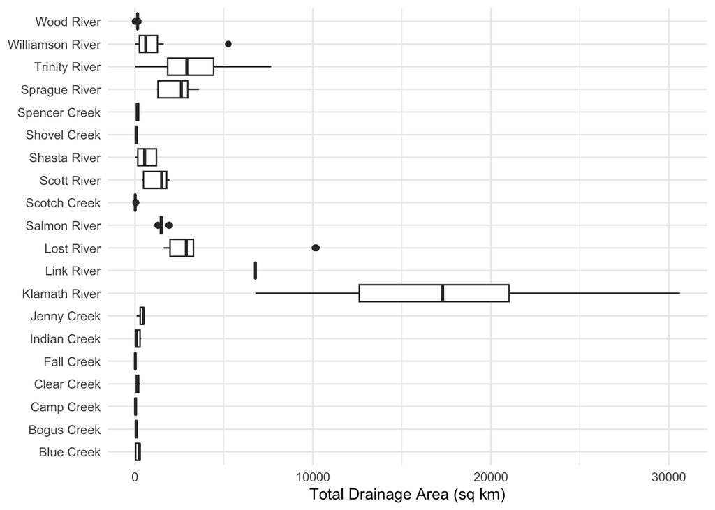

```r
ggplot(flowlines_ip_layers_all) +
  geom_boxplot(aes(x = gnis_nm, y = tot_da_sq_km)) +
  coord_flip() +
  labs(x = NULL, y = "Total Drainage Area (sq km)") +
  theme_minimal()
```

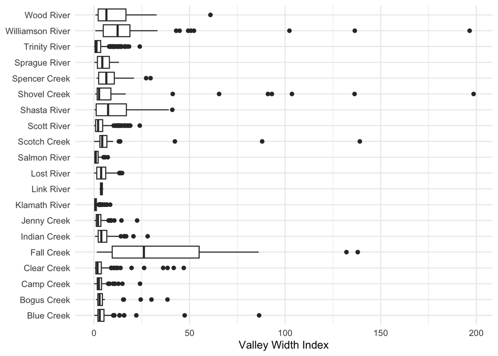

```r
ggplot(flowlines_ip_layers_all) +
  geom_boxplot(aes(x = gnis_nm, y = valley_width_index)) +
  coord_flip() +
  labs(x = NULL, y = "Valley Width Index") +
  theme_minimal()
```

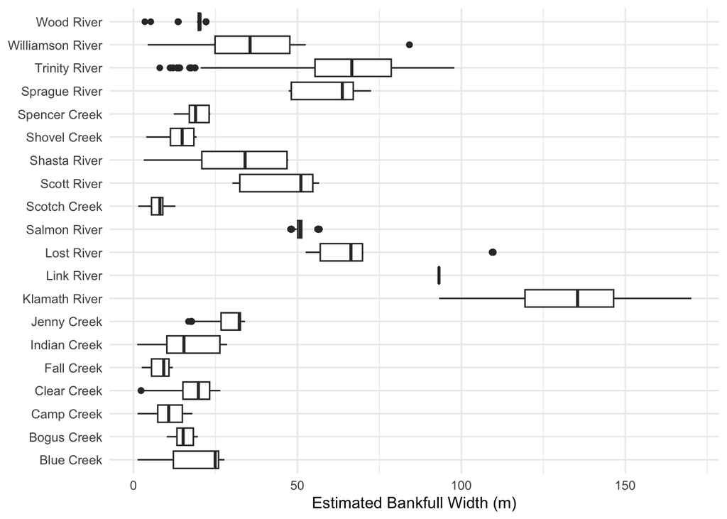

```r
ggplot(flowlines_ip_layers_all) +
  geom_boxplot(aes(x = gnis_nm, y = bf_width_m)) +
  coord_flip() +
  labs(x = NULL, y = "Estimated Bankfull Width (m)") +
  theme_minimal()
```

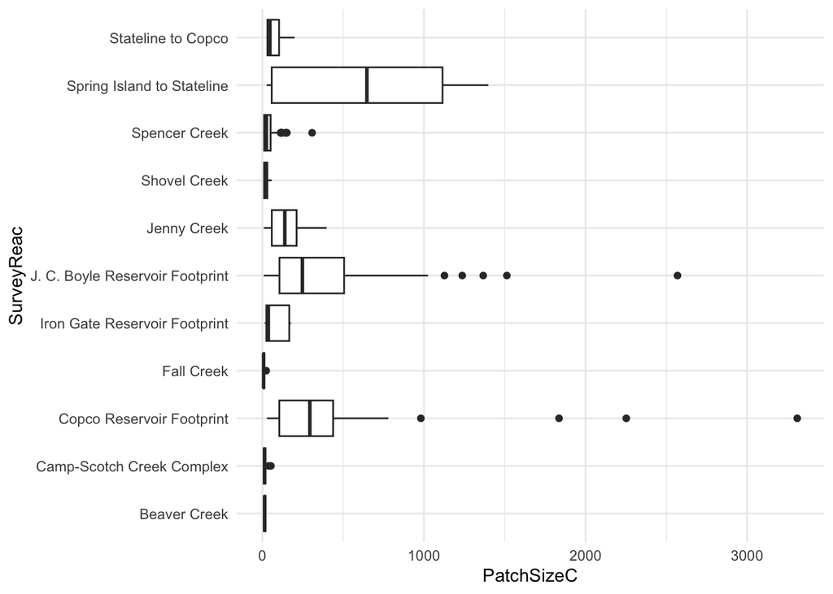

```r
ggplot(spawning_gravel) +
  geom_boxplot(aes(SurveyReac, y = PatchSizeC)) +
  coord_flip() +
  theme_minimal()
```

### Literature based thresholds for chinook spawning

Sources: [Burnett et al. 2007](https://www.fs.usda.gov/pnw/pubs/journals/pnw_2007_burnett001.pdf), [Busch et al. 2013](https://www.researchgate.net/figure/Curves-used-by-Busch-et-al-NOAA-Northwest-Fisheries-Science-Center-pers-comm-in_fig4_51529363), [Connor et al. 2015](https://www.skagitwatershed.org/wp-content/uploads/Tier-2-Tributary-composite-2015-02-04_final-draft-2.pdf), [Beechie et al. 2006](https://www.sciencedirect.com/science/article/abs/pii/S0169555X0600033X)

**Slope (gradient as %):**

*Busch & Agrawal agree on 0-2 as best; Connor et al’s 2-4 peak is likely system specific; >7 is universally unsuitable*

- High: <= 2% (optimal spawning gradient)
- Medium: > 2% to 4% (marginal but usable)
- Low: > 4% (too steep for most spawning)

**Annual Discharge (m3/s):**

*estimated using the power law and suitability from Agrawal et al.*

- High: >= 3 (sufficient flow for adult passage & spawning)
- Medium: 1-3 (marginal flow)
- Low: <1 (likely too small)

**Valley Width Index (vb_width / bf_width — confinement proxy):**

*Busch and Agrawal combined; Busch’s > 9 “good” and Agrawal’s > 4 “good” split the difference at > 4 as high*

- High: >4 (unconfined, gravel retention favorable)
- Medium: 1 to 4 (moderately confined)
- Low: < 1 (confined, poor gravel retention)

**Bankfull Width (bf_width_m):**

*Busch upper limit of 20 m and Connor’s 30–80 ft (~9–24 m) are broadly consistent; Busch’s > 4 m lower bound aligns with Connor’s < 10 ft bad category*

- High: >24 m (large enough for Chinook spawning)
- Medium: 9-24 m (marginal)
- Low: < 9 m (likely too narrow)

*Weights reflect relative importance to fall Chinook spawning and sum to 1.0. Adjust based on expert input if needed. Began with all weights equal.*

```r
weights <- list(
  slope  = 0.25,   # most limiting factor
  q     = 0.25,   # flow availability
  conf   = 0.25,   # gravel retention
  width  = 0.25    # channel size
)

score_slope <- function(s) {
  case_when(
    s <= 2          ~ 3,
    s > 2 & s <= 4  ~ 2,
    s > 4           ~ 1,
    TRUE            ~ NA_real_
  )
}

score_discharge <- function(q) {
  case_when(
    q >  3             ~ 3,   # good — sufficient for adult passage & spawning
    q >= 1 & q <= 3    ~ 2,   # okay — marginal flow
    q <  1             ~ 1,   # bad  — likely insufficient
    TRUE               ~ NA_real_
  )
}

score_confinement <- function(vwi) {
  case_when(
    vwi >= 4               ~ 3,
    vwi >= 1 & vwi < 4     ~ 2,
    vwi < 1                ~ 1,
    TRUE                   ~ NA_real_   # NAs flagged below
  )
}

score_width <- function(w) {
  case_when(
    w >= 24                ~ 3,
    w >= 9 & w < 24       ~ 2,
    w < 9                 ~ 1,
    TRUE                   ~ NA_real_
  )
}
```

| gnis_nm | min_ip | max_ip | mean_ip |
| --- | --- | --- | --- |
| Link River | 2.75 | 3.00 | 2.92 |
| Sprague River | 2.50 | 3.00 | 2.89 |
| Lost River | 2.25 | 3.00 | 2.87 |
| Scott River | 2.25 | 3.00 | 2.80 |
| Williamson River | 1.67 | 3.00 | 2.78 |
| Jenny Creek | 1.75 | 3.00 | 2.73 |
| Trinity River | 1.25 | 3.00 | 2.70 |
| Salmon River | 2.00 | 3.00 | 2.67 |
| Klamath River | 2.00 | 3.00 | 2.66 |
| Shasta River | 1.00 | 3.00 | 2.61 |
| Spencer Creek | 1.67 | 2.75 | 2.40 |
| Wood River | 2.00 | 2.50 | 2.32 |
| Blue Creek | 1.00 | 3.00 | 2.31 |
| Clear Creek | 1.00 | 3.00 | 2.13 |
| Indian Creek | 1.00 | 3.00 | 2.12 |
| Bogus Creek | 1.33 | 2.50 | 2.01 |
| Fall Creek | 1.00 | 2.25 | 1.87 |
| Shovel Creek | 1.50 | 2.33 | 1.87 |
| Camp Creek | 1.00 | 2.50 | 1.70 |
| Scotch Creek | 1.00 | 2.25 | 1.53 |

### Map summary of IP

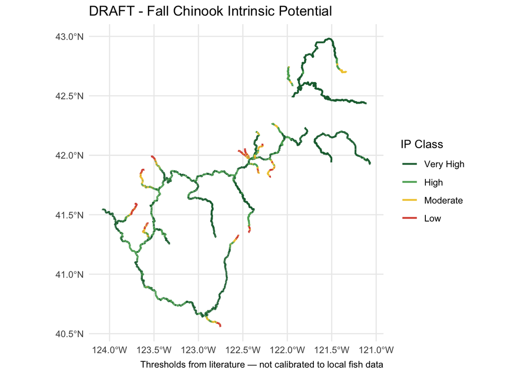